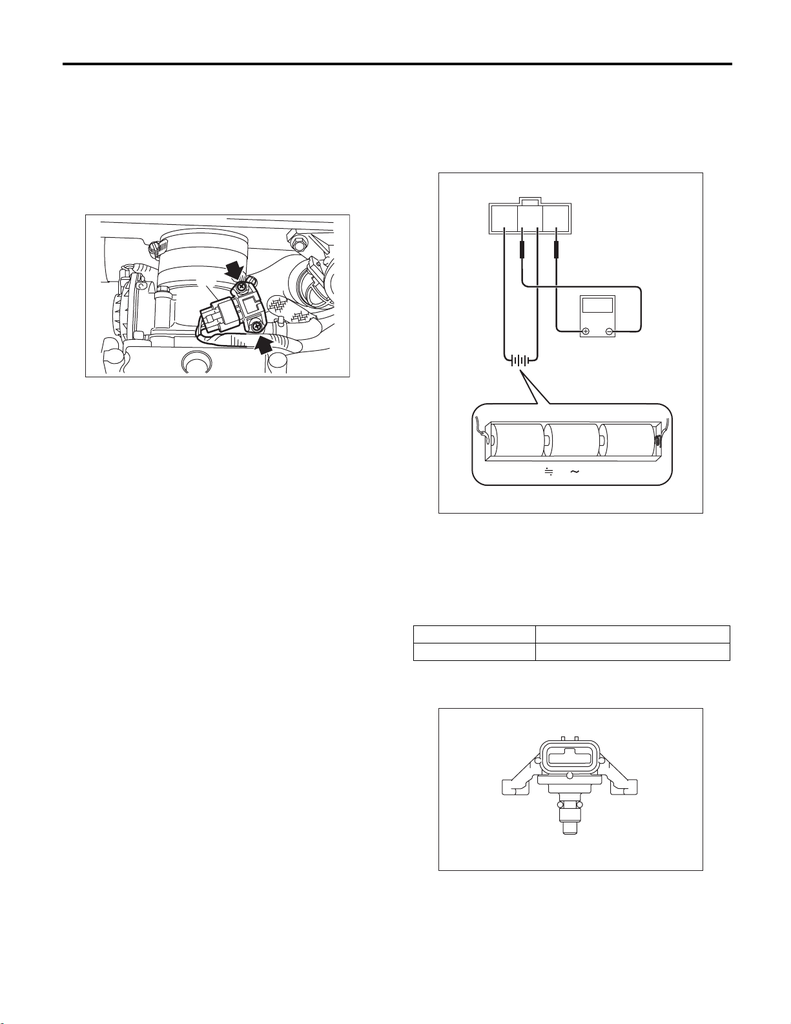

FU(STI)-41

Manifold Absolute Pressure Sensor

FUEL INJECTION (FUEL SYSTEMS)

10.Manifold Absolute Pressure

Sensor

A: REMOVAL

1) Disconnect the ground cable from battery.

2) Disconnect the connector (A) from the manifold

absolute pressure sensor, and remove the mani-

fold absolute pressure sensor from throttle body.

B: INSTALLATION

Install in the reverse order of removal.

NOTE:

Use new O-rings.

Tightening torque:

2 N·m (0.2 kgf-m, 1.5 ft-lb)

C: INSPECTION

1) Check that the manifold absolute pressure sen-

sor has no deformation, cracks or other damages.

2) Connect dry-cell battery positive terminal to ter-

minal No. 3 and dry-cell battery ground terminal to

terminal No. 2, circuit tester positive terminal to ter-

minal No. 1 and the circuit tester negative terminal

to terminal No. 2.

NOTE:

• Use new dry-cell batteries.

• Using circuit tester, check the voltage of a single

dry-cell battery is 1.6 V or more. And also check the

voltage of three batteries in series is between 4.8 V

and 5.2 V.

3) Check the voltage at a normal atmospheric pres-

sure.

NOTE:

The atmospheric pressure at higher altitude is low-

er than normal. Therefore, the voltage is lower than

the standard value.

4) Connect the Mighty Vac to the pressure port (A)

of manifold absolute pressure sensor.

FU-08344

(A)

Terminal No. Standard

1 (+) and 2 (–) Approx. 2.0 V (when 25°C (77°F))

FU-04491

V

3 2 1

1.5V

1.5V

1.5V

4.8 5.2V

FU-04492

(A)

[figure not shown]

FU(STI)-42

Manifold Absolute Pressure Sensor

FUEL INJECTION (FUEL SYSTEMS)

5) Check the voltage when generating vacuum and

positive pressure using Mighty Vac.

CAUTION:

Do not apply vacuum of less than –88 — 200

kPa (–0.9 — 2.04 kgf/cm

2

, –12.8 — 29.0 psi). Do-

ing so may damage the manifold absolute pres-

sure sensor.

NOTE:

When vacuum occurs at the pressure port of man-

ifold absolute pressure sensor, the voltage will drop

from the value as in step 3). When positive pres-

sure occurs, on the other hand, the voltage will rise.

Pressure Terminal No. Standard

–88 kPa (–0.9 kgf/cm

2

,

–12.8 psi)

1 (+) and 2 (–)

Approx. 0.8 V

(when 25°C

(77°F))

181 kPa (1.85 kgf/cm

2

,

26.2 psi)

Approx. 4.7 V

(when 25°C

(77°F))